# BaduelCabingan_gradient_boost

Ingrid Baduel and Stephanie Cabingan

2026-07-19

# Activity 14

# What is **gradient boosting (GB)**?

## - **What**: a powerful machine-learning technique

## - **For**: regression and classification problems

## - **How**: builds models sequentially by combining the outputs of several weak learners (decision trees) to form a strong predictive model

# How does GB differ from random forest (RF)?:

## **Ensemble Style**:

### - RF relies on Bagging (Bootstrap Aggregating) in which trees are grown completely independently in parallel

### - GB relies on Boosting in which trees are grown sequentially in a dependent chain where Tree *m* directly learns from the failures of Tree *m* - 1.

## **Tree Depth and Complexity**:

### - RF uses fully grown, deep decision trees designed to maximize variance reduction

### - GB uses shallow trees (often called weak learners or stumps) designed to systematically reduce bias

## **Aggregating Mechanism**:

### - RF treats all trees equally, obtaining finals outputs via a simple majority vote (classification) or uniform arithmetic average (regression)

### - GB weighs each tree’s contributions using a fractional shrinkage hyperparameter (learning rate)

## **Overfitting Sensitivity**:

### - RF is highly robust against overfitting; increasing the total number of trees stabilizes the error rate rather than degrading it

### - GB requires precise tuning; adding excessive trees allows the algorithm to fit the underlying random noise of the dataset

# What are the implementation variations by data type?

## **Gradient Boosting Regression**

### - Data Type: Continuous numeric variables

### - Loss Optimization: Typically minimizes Mean Squared Error (*L2*) Loss) or Mean Absolute Error (*L1* Loss)

### - Mechanics: The leaf nodes of each successive tree store the raw average numeric residual value of the partition samples. The final prediction is a direct summation of the base initialization mean and all scaled leaf steps

## **Gradient Boosting Binary Classification**

### - Data Type: Dichotomous categorical variables containing exactly two classes (e.g., 0 vs 1, Success vs Failure)

### - Loss Optimization: Minimizes Log-Loss (Bernoulli Negative Log-Likelihood)

### - Mechanics: The individual tree leaves store updates in log-odds units. During inference, these cumulative log-odds are mapped back to bounded probability distributions [0, 1] using a logistic sigmoid transformation function

## **Gradient Boosting Multi-Class Classification**

### - Data Type: Polychotomous categorical variables containing three or more distinct unordered classes

### - Loss Optimization: Minimizes Multinomial Multi-Class Log-Loss

### - Mechanics: For an analysis containing *K* unique categorical outcomes, the algorithm builds *K* separate, parallel tree streams during each sequential step. The cumulative raw outputs across all *K* dimensions are evaluated simultaneously and normalized into relative multiclass probabilities using a Softmax transformation function

# Which implementation are we exploring?

## **Chosen Implementation: Gradient Boosting Regression**

### - Reason: continuous outcome, and the residual at every step is just the raw prediction error (no log-odds or softmax conversion needed), which makes the update rule the most direct to code and verify by hand

### - General steps:

1. **Initialize** the model as a constant: the mean of the target variable, `F0(x) = mean(y)`
2. **For each boosting round *m*:**
   - Compute the residuals `residual_i = y_i - F_{m-1}(x_i)` (this *is* the negative gradient under squared-error loss)
   - Fit a shallow regression tree to the residuals `r`, using the predictors `X`
   - Update the model: `F_m(x) = F_{m-1}(x) + learning_rate * tree_m(x)`
3. **Final prediction** after *M* rounds: `F_M(x) = F0(x) + learning_rate * sum(tree_m(x))`

# Implementation

## **Dataset**

### - We’re reusing the herpetofauna survey dataset (`herpetozoa-033-095-s001.csv`), 49 sites across Palawan with coordinates, habitat type, elevation, and species richness

### - Predicting: **species richness (`SPPTotal`)**, a continuous count, from **elevation (`Elev`), latitude (`Lat`), and longitude (`Long`)**

### - The last few rows of the file are footnotes (asterisk/hashtag legend), not data, so those get dropped before modeling

```r
herps <- read.csv("herpetozoa-033-095-s001.csv", stringsAsFactors = FALSE)

# drop footnote rows at the bottom of the file (no valid SPPTotal)
herps$SPPTotal <- suppressWarnings(as.numeric(herps$SPPTotal))
herps <- herps[!is.na(herps$SPPTotal), ]

X <- herps[, c("Elev", "Lat", "Long")]
y <- herps$SPPTotal

str(X)
```

```
## 'data.frame':    49 obs. of  3 variables:
##  $ Elev: int  257 215 188 105 662 754 814 1020 474 425 ...
##  $ Lat : num  9.37 9.37 9.37 9.37 9.37 ...
##  $ Long: num  118 118 118 118 118 ...
```

```r
summary(y)
```

```
##    Min. 1st Qu.  Median    Mean 3rd Qu.    Max.
##   0.000   1.000   2.000   2.755   4.000   8.000
```

## **Step 1: The weak learner (a manual regression tree)**

### - No `rpart`/`tree` package used. At every node, every feature and every candidate split point is checked, and the split that reduces total sum of squared errors (SSE) the most is kept

### - Splitting stops once a max depth is hit or a node runs out of enough observations to split further

```r
# SSE of a set of values around their own mean
node_sse <- function(values) {
  if (length(values) == 0) return(0)
  sum((values - mean(values))^2)
}

# scans every feature/threshold combo, returns the split with the biggest
# SSE reduction. returns NULL if nothing improves on the parent node
best_split <- function(X, r, min_leaf = 3) {
  best <- list(feature = NA, threshold = NA, gain = 0)
  parent_sse <- node_sse(r)

  for (feat in colnames(X)) {
    values <- X[[feat]]
    candidates <- unique(sort(values))
    thresholds <- (candidates[-1] + candidates[-length(candidates)]) / 2

    for (thresh in thresholds) {
      left_idx <- values <= thresh
      right_idx <- !left_idx

      if (sum(left_idx) < min_leaf || sum(right_idx) < min_leaf) next

      split_sse <- node_sse(r[left_idx]) + node_sse(r[right_idx])
      gain <- parent_sse - split_sse

      if (gain > best$gain) {
        best <- list(feature = feat, threshold = thresh, gain = gain)
      }
    }
  }

  if (is.na(best$feature)) return(NULL)
  best
}

# recursively builds a regression tree as a nested list. a node is either a
# leaf (has $value) or a split (has $feature/$threshold/$left/$right)
build_tree <- function(X, r, max_depth = 2, min_leaf = 3, depth = 0) {
  if (depth >= max_depth || nrow(X) < (2 * min_leaf)) {
    return(list(value = mean(r)))
  }

  split <- best_split(X, r, min_leaf = min_leaf)
  if (is.null(split)) {
    return(list(value = mean(r)))
  }

  left_idx <- X[[split$feature]] <= split$threshold
  right_idx <- !left_idx

  left_node <- build_tree(X[left_idx, , drop = FALSE], r[left_idx],
                           max_depth, min_leaf, depth + 1)
  right_node <- build_tree(X[right_idx, , drop = FALSE], r[right_idx],
                            max_depth, min_leaf, depth + 1)

  list(feature = split$feature, threshold = split$threshold,
       left = left_node, right = right_node)
}

# pushes one row of X down the tree until it reaches a leaf
predict_one <- function(tree, row) {
  while (is.null(tree$value)) {
    if (row[[tree$feature]] <= tree$threshold) {
      tree <- tree$left
    } else {
      tree <- tree$right
    }
  }
  tree$value
}

# predicts for a whole data frame
predict_tree <- function(tree, X) {
  sapply(seq_len(nrow(X)), function(i) predict_one(tree, X[i, , drop = FALSE]))
}
```

## **Step 2: The boosting loop**

### - Start from the mean, repeatedly fit a tree to the current residuals, and nudge predictions toward those residuals with a small learning rate

```r
gradient_boost <- function(X, y, n_trees = 100, learning_rate = 0.1,
                            max_depth = 2, min_leaf = 3) {

  init_pred <- mean(y)
  F_current <- rep(init_pred, length(y))
  trees <- vector("list", n_trees)
  train_mse <- numeric(n_trees)

  for (m in seq_len(n_trees)) {
    residuals <- y - F_current
    tree_m <- build_tree(X, residuals, max_depth = max_depth,
                          min_leaf = min_leaf)
    tree_pred <- predict_tree(tree_m, X)

    F_current <- F_current + learning_rate * tree_pred
    trees[[m]] <- tree_m
    train_mse[m] <- mean((y - F_current)^2)
  }

  list(trees = trees, init_pred = init_pred,
       learning_rate = learning_rate, train_mse = train_mse)
}

predict_gb <- function(model, X_new) {
  F_pred <- rep(model$init_pred, nrow(X_new))
  for (tree_m in model$trees) {
    F_pred <- F_pred + model$learning_rate * predict_tree(tree_m, X_new)
  }
  F_pred
}
```

## **Step 3: Fitting the model**

### - 100 trees, learning rate of 0.1, max depth of 2 – conservative settings given the small sample size (49 sites)

```r
gb_model <- gradient_boost(X, y, n_trees = 100, learning_rate = 0.1,
                            max_depth = 2, min_leaf = 3)

c(first_iteration = gb_model$train_mse[1],
  last_iteration = gb_model$train_mse[length(gb_model$train_mse)])
```

```
## first_iteration  last_iteration
##       3.9569670       0.5452856
```

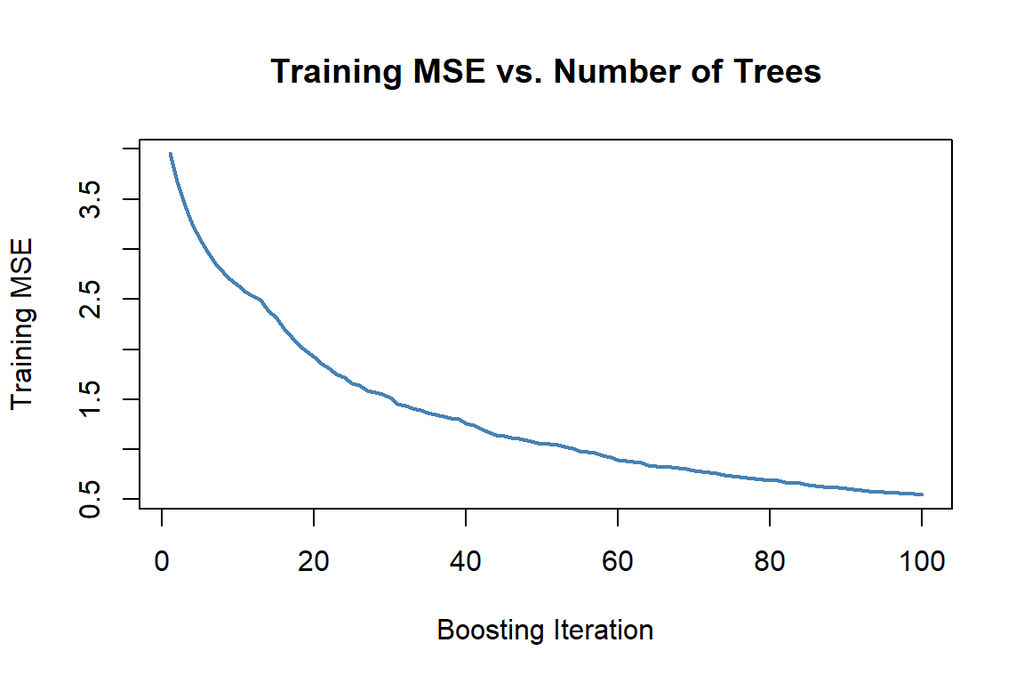

```r
plot(gb_model$train_mse, type = "l", lwd = 2, col = "steelblue",
     xlab = "Boosting Iteration", ylab = "Training MSE",
     main = "Training MSE vs. Number of Trees")
```

### - Training error drops quickly in the first several rounds and then decreases more slowly, which is the expected boosting pattern

## **Step 4: Checking the fit**

```r
fitted_values <- predict_gb(gb_model, X)

results <- data.frame(
  site = herps$Sites,
  actual_richness = y,
  predicted_richness = round(fitted_values, 2)
)
head(results, 10)
```

```
##          site actual_richness predicted_richness
## 1    ASG_ET1#               0               1.97
## 2    ASG_ET4#               0               0.98
## 3    ESG_ET5#               0               0.22
## 4     CVT_ET6               0               0.36
## 5     OGF_ET8               1               1.28
## 6    OGF_ET10               1               1.21
## 7    OGF_ET12               1               1.28
## 8     OGF_MT1               1               1.86
## 9     OGF_MT4               1               1.46
## 10 OGF_ALAMT1               1               1.53
```

```r
final_mse <- mean((y - fitted_values)^2)
final_rmse <- sqrt(final_mse)
c(MSE = final_mse, RMSE = final_rmse)
```

```
##       MSE      RMSE
## 0.5452856 0.7384346
```

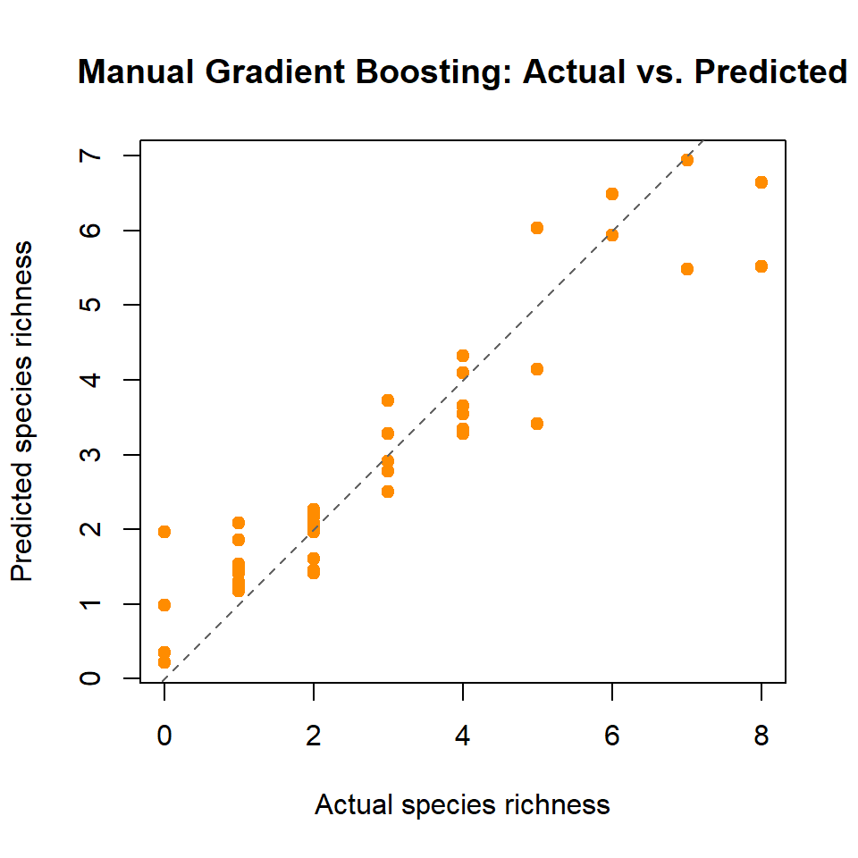

```r
plot(y, fitted_values, xlab = "Actual species richness",
     ylab = "Predicted species richness",
     main = "Manual Gradient Boosting: Actual vs. Predicted",
     pch = 19, col = "darkorange")
abline(a = 0, b = 1, lty = 2, col = "gray40")
```

### - Predictions track actual richness fairly closely on the training data, though with no held-out test set this only confirms the boosting mechanics work (residuals shrinking as trees accumulate), not that the model generalizes – a train/test split would be a reasonable next step given how small this dataset is

# Takeaways

## - Under squared-error loss, the “gradient” is just the residual, so boosting reduces to a loop of fitting the leftover error and taking a small step toward correcting it

## - Number of trees, learning rate, and tree depth are the main levers – pushing any of them too far (too many trees, too high a learning rate, too-deep trees) is what pushes GB from underfitting toward overfitting, unlike RF where adding trees rarely hurts